# 1_Scatterplots_Hisograms_Barplots

## Position argument

3 options:

- `position = "stack"`
- `position = "dodge"`
- `position = "fill"`

The default is “stack”. This places bars corresponding to different values of the specified categorical on top of each other (each bar starts where the last bar ends).

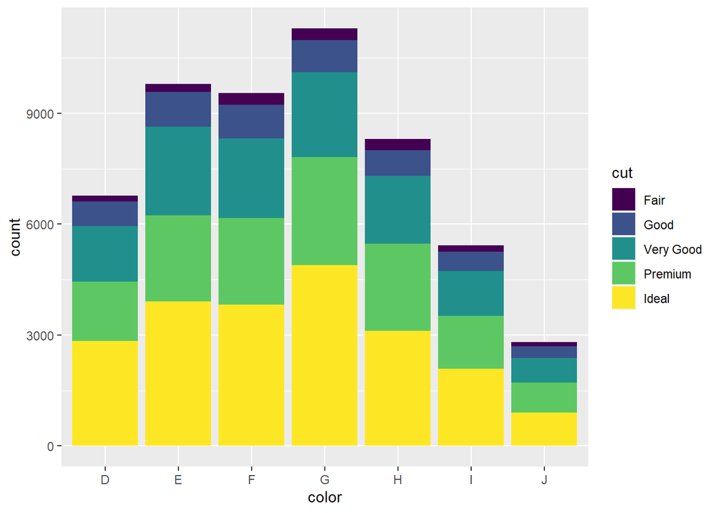

```r
ggplot(diamonds, aes(x = color)) +
  geom_bar(aes(fill = cut), position = "stack")
```

Stacking can cause confusion or can be misinterpreted. Your audience could interpret that the bars overlay (all bars start at 0) or that the graphs are stacked on top of each other (each bar starts counting where the last one ends, which is actually the case in ggplot).

To avoid this possibility for multiple interpretations caused the stacking, you may also use “dodge”

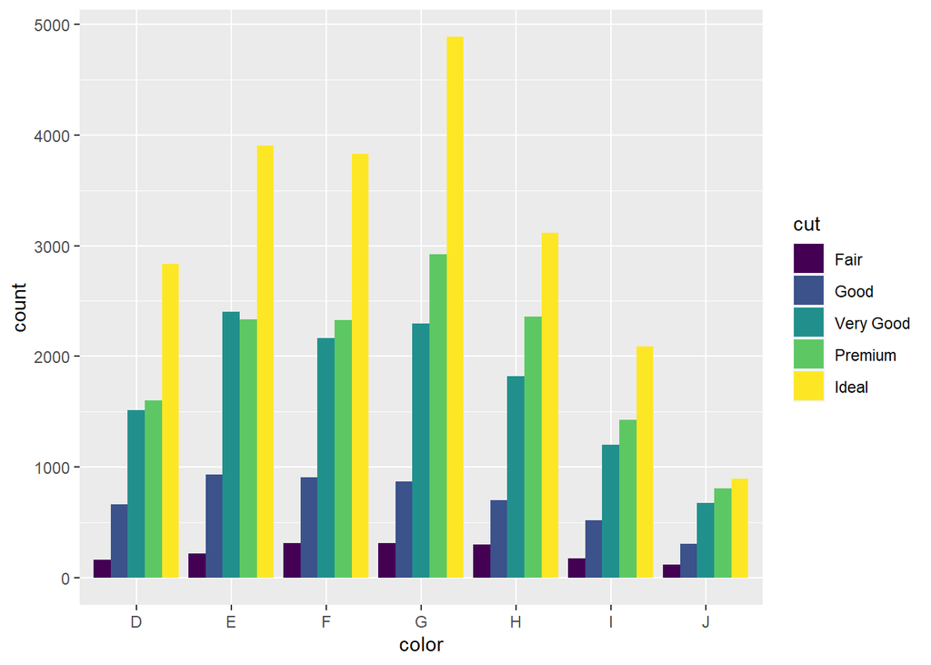

```r
ggplot(diamonds, aes(x = color)) +
  geom_bar(aes(fill = cut), position = "dodge")
```

Finally, if you want to highlight the percent distribution within each category you may use `position = fill`. However **this may lead your audience to think for example that there are as many “good” diamonds in color E than in color J**, when in reality there are many more good diamonds with the color E (see the previous *dodged* graph):

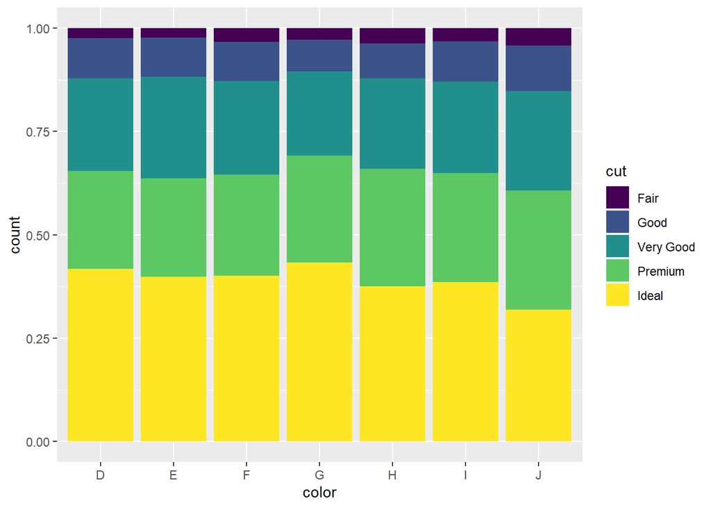

```r
ggplot(diamonds, aes(x = color)) +
  geom_bar(aes(fill = cut), position = "fill")
```

## `stat = "identity"` - barplots of variables other than `count`

By default `geom_bar()` counts the number of rows to produce the output of the `y` variable `count`.

We may however pre-process the data to create the desired numerical value per category and then use `stat = "identity"` to indicate that we want to set that value as the `y` aesthetic instead of the default row-counting.

As an example, let us compute the average price of diamonds for each combination of `cut` and `clarity` using `group_by` and `summarize`:

```r
aux <-
  diamonds %>%
    group_by(cut, clarity) %>%
    summarize(
      n_diamonds = n(), # counts the number of diamonds in each group
      avg_price = mean(price)
    )
```

[output not shown]

```r
aux
```

```
# A tibble: 40 × 4
# Groups:   cut [5]
   cut   clarity n_diamonds avg_price
   <ord> <ord>        <int>     <dbl>
 1 Fair  I1             210     3704.
 2 Fair  SI2            466     5174.
 3 Fair  SI1            408     4208.
 4 Fair  VS2            261     4175.
 5 Fair  VS1            170     4165.
 6 Fair  VVS2            69     3350.
 7 Fair  VVS1            17     3871.
 8 Fair  IF               9     1912.
 9 Good  I1              96     3597.
10 Good  SI2           1081     4580.
# … with 30 more rows
```

If we attempt to create a barplot as before we get some weird output. Can you give an interpretation of this? (solution will be given after class in this same notebook)

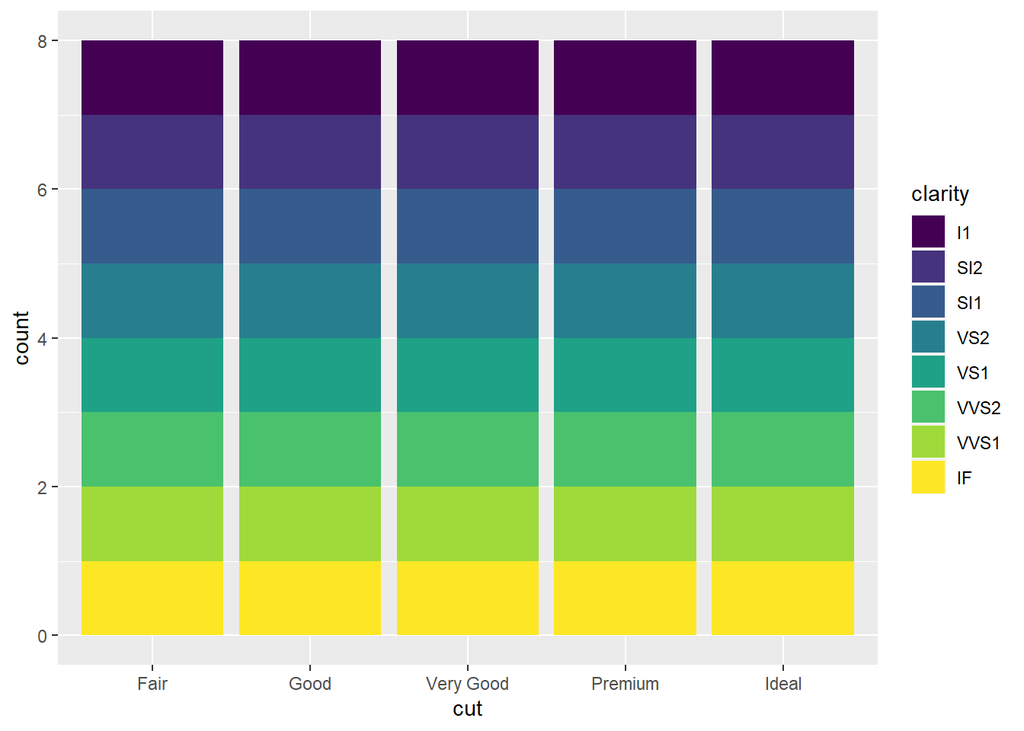

```r
ggplot(aux, aes(x = cut, fill = clarity)) +
  geom_bar()
```

```r
By default geom_bar() uses stat = "count", which creates the count varaible based
on the number of rows corresponding to each category.

We get the output above because in the dataframe aux there are 8 rows
corresponding to every `cut`

With regard to the colors, since each category `cut` can be further split
into 8 clarity categories we get a value of 1 for every color, since there is
only one row per combination of `cut` and `clarity`
```

To produce the desired output we need to specify `avg_price` as the `y` aesthetic. **When explicitly specifying a `y` variable in a bar plot you also need to specify `stat = "identity"`** to override the default `stat = "count"` (which counts the number of rows). Otherwise you will get an error (feel free to check this):

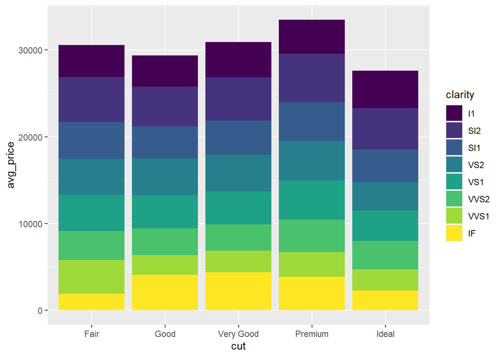

```r
ggplot(aux, aes(x = cut, y = avg_price, fill = clarity)) +
  geom_bar(stat = "identity")
```

### Understanding the default `stat = "count"`

Now that you know how to use `stat = "identity"`, we may explore how the default `stat = "count"` works. Let us remember the behavior of the basic bar plot. Essentially the code below counts the number of diamonds within each color category assigns that to the `y` variable.

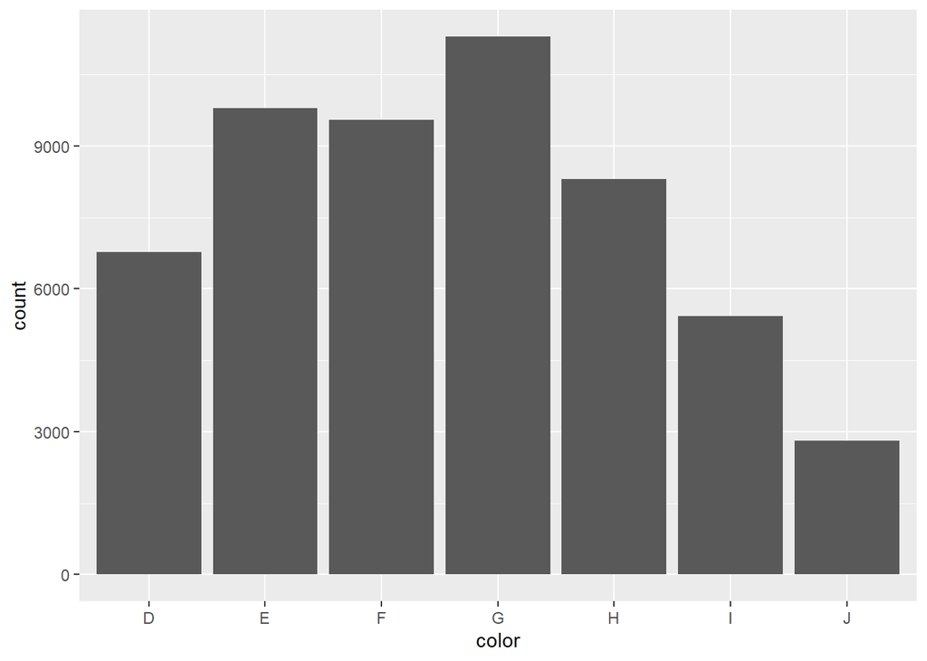

```r
ggplot(diamonds, aes(x = color)) +
  geom_bar()
```

We attain the same if we explicitly state the default argument `stat = "count"`

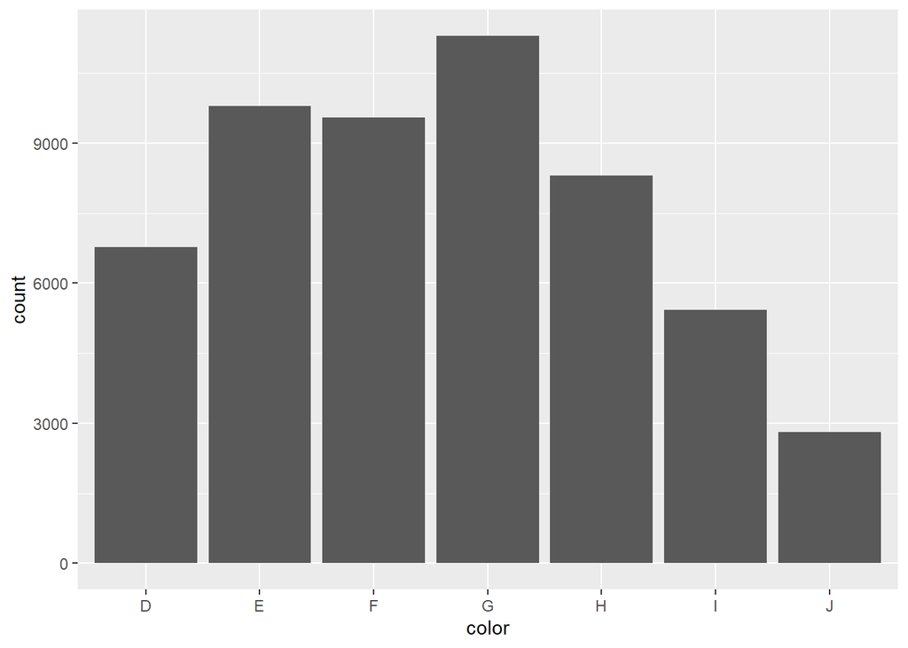

```r
# This is exactly the same, only making the default
# argument stat = "count" explicit
ggplot(diamonds, aes(x = color)) +
  geom_bar(stat = "count")
```

Now let us create an `aux` intermediate result using `group_by()` to count the number of diamonds in each group and then use `stat = "identity"` to depict that as the `y` variable. You will see we reach the exact same output:

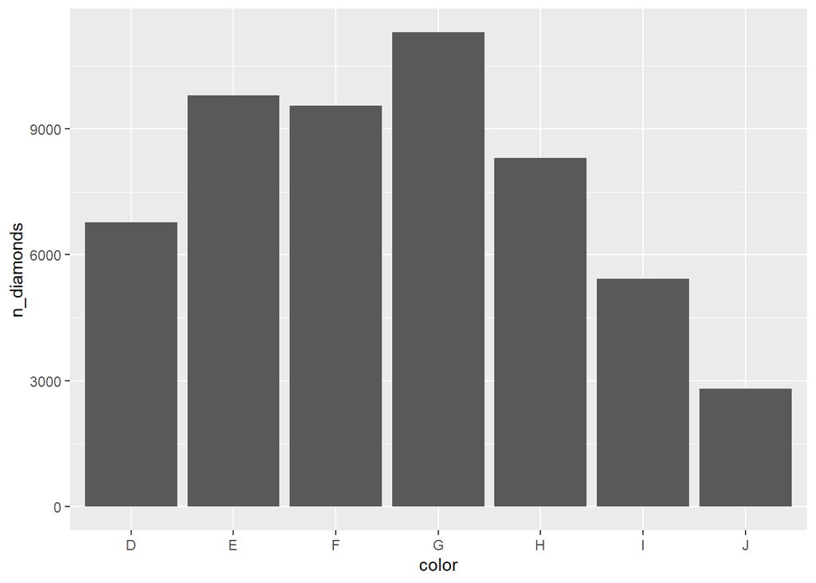

```r
aux <-
  diamonds %>%
    group_by(color) %>%
    summarize(
      n_diamonds = n() # count the number of diamonds in each color category
    )

ggplot(aux, aes(x = color, y = n_diamonds)) +
  geom_bar(stat = "identity")
```

At this point the difference between `stat = "count"` and `stat = "identity"` should be clear to you.

## Exercise 6

Generate the following graph (expected output below) based on the previously computed average prices per cut and clarity:

```r
aux <-
  diamonds %>%
    group_by(cut, clarity) %>%
    summarize(
      avg_price = mean(price)
    )

aux
```

```
# A tibble: 40 × 3
# Groups:   cut [5]
   cut   clarity avg_price
   <ord> <ord>       <dbl>
 1 Fair  I1          3704.
 2 Fair  SI2         5174.
 3 Fair  SI1         4208.
 4 Fair  VS2         4175.
 5 Fair  VS1         4165.
 6 Fair  VVS2        3350.
 7 Fair  VVS1        3871.
 8 Fair  IF          1912.
 9 Good  I1          3597.
10 Good  SI2         4580.
# … with 30 more rows
```

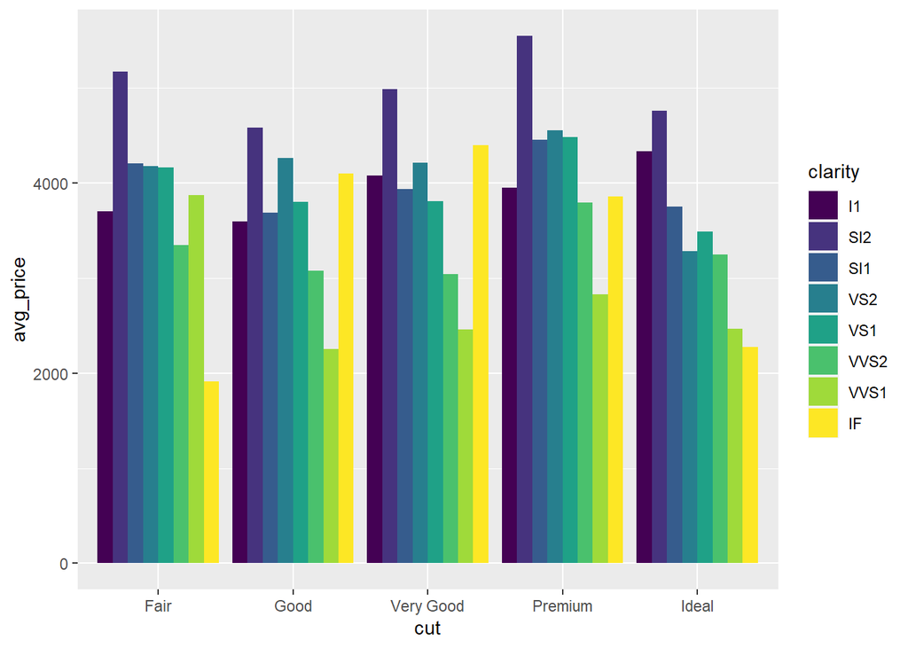

```r
ggplot(aux, aes(x = cut, y = avg_price, fill = clarity)) +
  geom_bar(stat = "identity", position = "dodge")
```

## Exercise 7

Produce a graph similar to that of exercise 6, but this time depict the price of the most expensive diamond for each combination of `cut` and `clarity`. Expected output below:

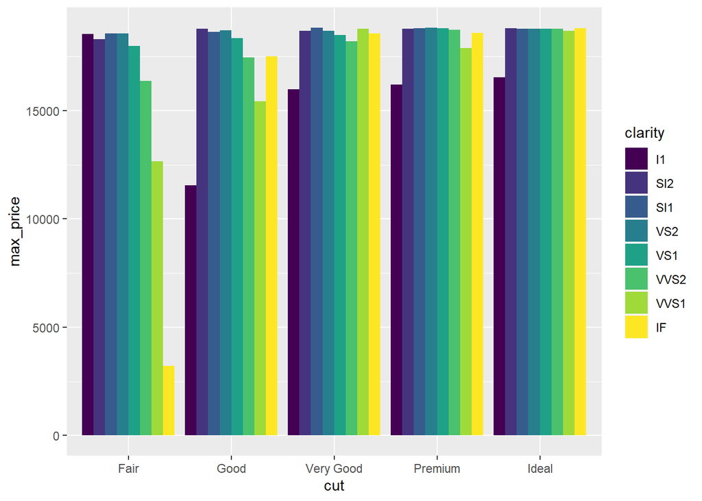

```r
aux <-
  diamonds %>%
    group_by(cut, clarity) %>%
    summarize(
      max_price = max(price)
    )

aux %>%
  ggplot(aes(x = cut, y = max_price, fill = clarity)) +
    geom_bar(stat = "identity", position = "dodge")
```